# Module 4. Linear mixed-effects models

Slides

**Simulated data**

All examples use simulated data from fictional studies. Results illustrate methods; they are not empirical findings.

## Learning outcomes

1. **4.1** Write random-intercept and random-slope models and explain every term
2. **4.2** Distinguish fixed effects, random effects and residual variation; variance components and ICC
3. **4.3** Code time as continuous, categorical, centred or nonlinear
4. **4.4** Fit a group-by-time model with `lme4`/`lmerTest` and `nlme`; report the difference in mean change
5. **4.5** Explain ML versus REML
6. **4.6** Obtain and interpret BLUPs and shrinkage

# Building the model

## Every participant has a trajectory of their own

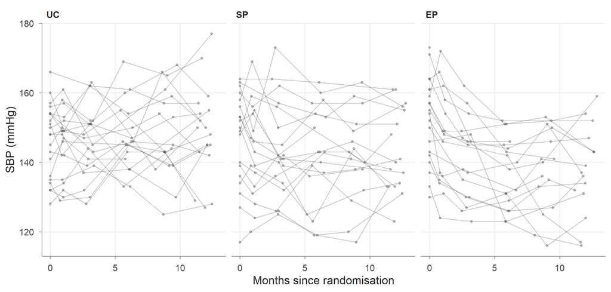

## Three sources of variation

| Part | Symbol | Describes | WALK example |
| --- | --- | --- | --- |
| Fixed effects | $\boldsymbol\beta$ | Mean trajectory by arm | Mean SBP over time in EP |
| Random effects | $b_{0i}, b_{1i}$ | Participant’s departure from the mean line | Participant W017 is 15 mmHg above average |
| Residual error | $\varepsilon_{ij}$ | Measurement around own line | Today’s reading 4 mmHg high |

- Random effects are not estimated one by one: we estimate their **variance** ($\tau_0^2$, $\tau_1^2$, $\tau_{01}$)
- Variance components: $\tau_0^2$, $\tau_1^2$, $\tau_{01}$, $\sigma^2$

## The model’s line for each person is a compromise

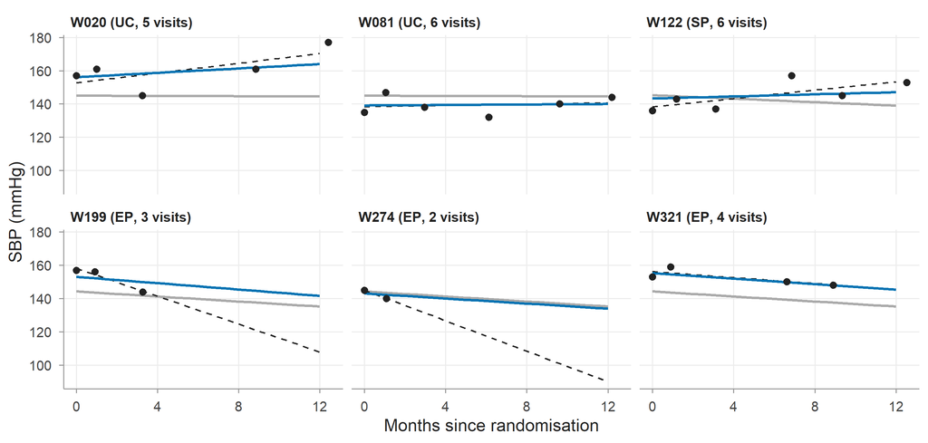

Dashed: participant’s own OLS line. Blue: model prediction. Grey: arm mean.

# Random intercepts

## Random intercept: parallel lines at different heights

$$y_{ij} = \beta_0 + \beta_1 t_{ij} + \beta_2 \text{SP}_i + \beta_3 \text{EP}_i + \beta_4 t_{ij}\text{SP}_i + \beta_5 t_{ij}\text{EP}_i + b_{0i} + \varepsilon_{ij}$$

$$b_{0i} \sim N(0, \tau_0^2), \qquad \varepsilon_{ij} \sim N(0, \sigma^2), \quad \text{independent}$$

- $\beta_4, \beta_5$: difference in mean slope vs UC (the estimands)
- $b_{0i}$: participant’s level relative to their arm’s mean line
- All participants in an arm share one slope

## One correlation for every pair of visits: the ICC

$$\operatorname{Corr}(y_{ij}, y_{ik}) = \rho_I = \frac{\tau_0^2}{\tau_0^2 + \sigma^2}$$

```r
m_ri <- lmer(sbp ~ month * arm + (1 | id), data = walk, control = lmer_ctrl)
VarCorr(m_ri)
```

```
#>  Groups   Name        Std.Dev.
#>  id       (Intercept) 12.08
#>  Residual              6.37
```

```r
icc_lmer(m_ri)
```

```
#> [1] 0.7826
```

- $\hat\tau_0 =$ 12.1, $\hat\sigma =$ 6.4 mmHg, ICC = 0.78

## The data say correlation decays with distance

```
#>       0    1    3    6    9   12
#> 0  1.00 0.87 0.78 0.70 0.72 0.69
#> 1  0.87 1.00 0.83 0.78 0.74 0.73
#> 3  0.78 0.83 1.00 0.78 0.75 0.75
#> 6  0.70 0.78 0.78 1.00 0.79 0.78
#> 9  0.72 0.74 0.75 0.79 1.00 0.84
#> 12 0.69 0.73 0.75 0.78 0.84 1.00
```

- Observed: 0.87 (months 0, 1) down to 0.69 (months 0, 12)
- Random intercept model: 0.78 everywhere

## Try it

Workbook exercise 1: fit the random-intercept model, compute the ICC and compare it with the observed correlations.

# Random slopes

## Random slopes let each participant change at their own rate

$$y_{ij} = \mathbf{x}_{ij}^\top\boldsymbol\beta + b_{0i} + b_{1i} t_{ij} + \varepsilon_{ij},
\qquad
\begin{pmatrix} b_{0i} \\ b_{1i} \end{pmatrix} \sim N\!\left(\mathbf{0}, G\right),
\quad G = \begin{pmatrix} \tau_0^2 & \tau_{01} \\ \tau_{01} & \tau_1^2 \end{pmatrix}$$

- $b_{1i}$: participant’s slope minus their arm’s mean slope
- $\tau_1^2$: variance of slopes; $\tau_{01}$: covariance of intercepts and slopes
- Matrix form: $\mathbf{y}_i = X_i\boldsymbol\beta + Z_i\mathbf{b}_i + \boldsymbol\varepsilon_i$, $\;V_i = Z_iGZ_i^\top + \sigma^2 I$

## The linear-time reference model

```r
m_lin <- lmer(sbp ~ month * arm + (1 + month | id),
              data = walk, control = lmer_ctrl)
VarCorr(m_lin)
```

```
#>  Groups   Name        Std.Dev. Corr
#>  id       (Intercept) 12.413
#>           month        0.515   -0.23
#>  Residual              5.915
```

```r
round(fixef(m_lin), 3)
```

```
#> (Intercept)       month       armSP       armEP month:armSP month:armEP
#>     145.010      -0.034       0.305      -0.764      -0.490      -0.724
```

## Allowing for slope variation widens the SEs of slope differences

| Term | SE, random intercept | SE, random slope |
| --- | --- | --- |
| `month:armSP` | 0.085 | 0.106 |
| `month:armEP` | 0.086 | 0.107 |

- Slope variation between participants is part of the uncertainty about the mean slope
- Ignoring it makes the treatment comparison look too precise

## In a random-slope model variance and correlation depend on time

$$\operatorname{Var}(y_{ij}) = \tau_0^2 + 2\tau_{01}t_{ij} + \tau_1^2 t_{ij}^2 + \sigma^2$$

```r
cov_to_cor(implied_cov_lmer(m_lin, c(0, 1, 3, 6, 9, 12)))
```

```
#>       0    1    3    6    9   12
#> 0  1.00 0.81 0.81 0.79 0.75 0.72
#> 1  0.81 1.00 0.81 0.79 0.77 0.73
#> 3  0.81 0.81 1.00 0.80 0.78 0.76
#> 6  0.79 0.79 0.80 1.00 0.80 0.79
#> 9  0.75 0.77 0.78 0.80 1.00 0.81
#> 12 0.72 0.73 0.76 0.79 0.81 1.00
```

## Implied variance is quadratic in time

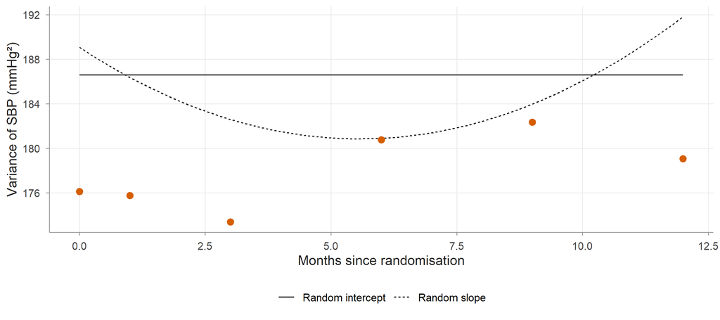

## Is the random slope needed? Test on the boundary

```r
anova(m_ri, m_lin, refit = FALSE)
```

```
#> Data: walk
#> Models:
#> m_ri: sbp ~ month * arm + (1 | id)
#> m_lin: sbp ~ month * arm + (1 + month | id)
#>       npar   AIC   BIC logLik -2*log(L) Chisq Df Pr(>Chisq)
#> m_ri     8 13482 13527  -6733     13466
#> m_lin   10 13439 13494  -6709     13419  47.3  2    5.3e-11 ***
#> ---
#> Signif. codes:  0 '***' 0.001 '**' 0.01 '*' 0.05 '.' 0.1 ' ' 1
```

```r
p_boundary_mixture(lr_test(m_ri, m_lin)$chisq, df_mix = c(1, 2))
```

```
#> [1] 2.961e-11
```

- Same fixed effects, so REML likelihoods are comparable (`refit = FALSE`)
- $\tau_1^2 = 0$ is on the boundary: use a 50:50 mixture of $\chi^2_1$ and $\chi^2_2$ (Self and Liang 1987; Stram and Lee 1994)

## Try it

Workbook exercises 2 and 3: fit the random-slope model, compute implied variances and correlations, and test the random slope.

# Coding time

## Centring time changes the question, not the model

```r
walk <- walk |> mutate(month12 = month - 12)
m_c12 <- lmer(sbp ~ month12 * arm + (1 + month12 | id),
              data = walk, control = lmer_ctrl)
round(cbind(month0 = fixef(m_lin), month12 = fixef(m_c12)), 3)
```

```
#>              month0 month12
#> (Intercept) 145.010 144.606
#> month        -0.034  -0.034
#> armSP         0.305  -5.574
#> armEP        -0.764  -9.446
#> month:armSP  -0.490  -0.490
#> month:armEP  -0.724  -0.724
```

- `armSP`, `armEP` now = differences **at month 12**; slopes unchanged

## Straight lines miss the levelling off

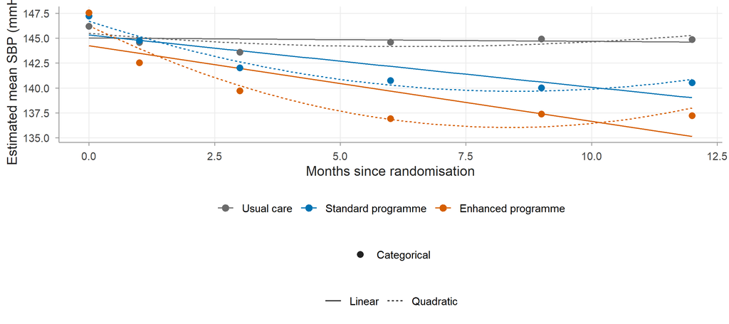

## Four ways to code time

| Coding | Intercept means | Arm effect means | Use when |
| --- | --- | --- | --- |
| `month` | Mean at month 0 | Difference at month 0 | Rate of change is the question |
| `month - 12` | Mean at month 12 | Difference at month 12 | Interest in a specific time |
| `visit_f` | Mean at baseline | Difference at baseline | Few fixed visits, estimand at one visit |
| `month + month^2` | Mean at month 0 | Difference at month 0 | Curved trajectories (Module 9) |

## Try it

Workbook exercise 4: centre time at month 12 and explain the arm coefficients.

# The primary analysis

## The primary model: a mean for every arm and visit

```r
m_cat <- lmer(sbp ~ visit_f * arm + (1 + month | id),
              data = walk, control = lmer_ctrl)
round(fixef(m_cat)[c("visit_f12", "visit_f12:armSP", "visit_f12:armEP")], 2)
```

```
#>       visit_f12 visit_f12:armSP visit_f12:armEP
#>           -1.33           -5.38           -8.97
```

- Mean: scheduled visit (factor) by arm, 18 parameters, no shape assumption
- Covariance: random intercept and slope on **actual** time
- All 360 participants, 1897 observations

## The estimand with `emmeans`

```r
emm   <- emmeans(m_cat, ~ visit_f | arm)
chg12 <- contrast(emm, list(chg12 = c(-1, 0, 0, 0, 0, 1)))
dmc12 <- contrast(chg12, "trt.vs.ctrl", by = NULL, adjust = "none")
summary(dmc12, infer = TRUE)
```

```
#>  contrast            estimate   SE  df lower.CL upper.CL t.ratio p.value
#>  chg12 SP - chg12 UC    -5.38 1.42 483    -8.17    -2.58  -3.782  0.0002
#>  chg12 EP - chg12 UC    -8.97 1.44 491   -11.79    -6.15  -6.243 <0.0001
#>
#> Degrees-of-freedom method: satterthwaite
#> Confidence level used: 0.95
```

## Estimates are close to the truth (we can check only because the data are simulated)

| Month 12 (mmHg) | Estimate (95% CI) | Truth |
| --- | --- | --- |
| Change, UC | -1.3 (-3.3 to 0.7) | -2.1 |
| Change, SP | -6.7 (-8.7 to -4.7) | -6.7 |
| Change, EP | -10.3 (-12.3 to -8.3) | -10.2 |
| SP minus UC | -5.4 (-8.2 to -2.6) | -4.6 |
| EP minus UC | -9.0 (-11.8 to -6.1) | -8.1 |

## Basic residual checks

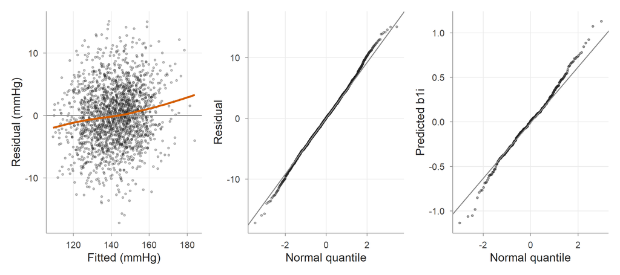

## `nlme::lme` gives the same answer

```r
m_cat_lme <- lme(sbp ~ visit_f * arm, random = ~ 1 + month | id,
                 data = walk, method = "REML")
max(abs(fixef(m_cat) - nlme::fixef(m_cat_lme)))
```

```
#> [1] 8.481e-06
```

|  | Estimate EP − UC | 95% CI | df |
| --- | --- | --- | --- |
| `lmer` (Satterthwaite) | -8.97 | -11.79 to -6.15 | 491 |
| `lme` (containment) | -8.97 | -11.79 to -6.15 | 1522 |

## Reporting the primary analysis

**Reporting example**

Compared with usual care, SBP fell by an additional 5.4 mmHg with the standard programme (95% CI 2.6 to 8.2) and 9.0 mmHg with the enhanced programme (6.1 to 11.8) from baseline to month 12, estimated from a linear mixed model with visit-by-arm fixed effects and a random intercept and slope on actual time (REML, all 360 participants, valid under MAR).

## Try it

Workbook exercise 5: fit the primary model, obtain the difference in mean change at month 12, and refit it with `nlme::lme`.

# Estimation and prediction

## REML corrects the downward bias of ML variance estimates

- ML: like dividing a sum of squares by $n$; ignores the $p$ df used by $\hat{\boldsymbol\beta}$
- REML: maximises the likelihood of residual contrasts, like dividing by $n - 1$

$$\ell_R(\boldsymbol\theta) = \ell\big(\hat{\boldsymbol\beta}(\boldsymbol\theta), \boldsymbol\theta\big) - \tfrac{1}{2}\log\Big|\textstyle\sum_i X_i^\top V_i^{-1}X_i\Big|$$

## In WALK the difference is tiny; in small studies it is not

```r
cbind(REML = varcomp_table(m_cat)$value,
      ML   = varcomp_table(m_cat_ml)$value)
```

```
#>         REML      ML
#> [1,] 12.3729 12.3216
#> [2,]  0.5421  0.5394
#> [3,] -0.2347 -0.2350
#> [4,]  5.6196  5.5922
```

- Rows: $\tau_0$, $\tau_1$, correlation, $\sigma$
- Simulation in the notes: 16 participants, true $\tau_0^2 = 121$; ML about 12% too small on average, REML close

## When to use each

- **REML**: final model; variance components; comparing random-effects or covariance structures with the **same** fixed effects
- **ML**: likelihood-ratio tests, AIC, BIC for models with **different** fixed effects
- `anova()` on `lmer` fits refits with ML automatically

```r
anova(m_lin, m_quad)  # linear vs quadratic mean: ML refit
```

```
#> Data: walk
#> Models:
#> m_lin: sbp ~ month * arm + (1 + month | id)
#> m_quad: sbp ~ (month + I(month^2)) * arm + (1 + month | id)
#>        npar   AIC   BIC logLik -2*log(L) Chisq Df Pr(>Chisq)
#> m_lin    10 13435 13491  -6708     13415
#> m_quad   13 13326 13399  -6650     13300   115  3     <2e-16 ***
#> ---
#> Signif. codes:  0 '***' 0.001 '**' 0.01 '*' 0.05 '.' 0.1 ' ' 1
```

## BLUPs: predicted random effects

$$\hat{\mathbf{b}}_i = \hat G Z_i^\top \hat V_i^{-1}(\mathbf{y}_i - X_i\hat{\boldsymbol\beta}),
\qquad
\hat b_{0i} = \frac{n_i\tau_0^2}{n_i\tau_0^2 + \sigma^2}\,(\bar y_i - \bar{\mathbf{x}}_i^\top\hat{\boldsymbol\beta})$$

- Random effects are **predicted**, not estimated
- Shrinkage factor near 1 with many precise observations, near 0 with few noisy ones

## Slopes shrink strongly toward the arm mean

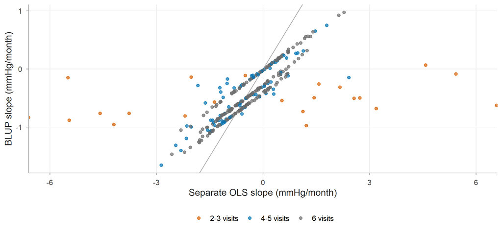

## Try it

Workbook exercise 6: compute OLS and BLUP slopes and draw the shrinkage plot.

# Wrap-up

## Common mistakes

- Reading `armSP` as the treatment effect in a model with interactions
- Quoting one ICC for a random-slope model
- Comparing REML fits with different fixed effects
- Dropping random slopes because a test is borderline
- Treating BLUPs as data; ranking people by BLUPs without uncertainty
- Leaving the `emmeans` default adjustment unreported

## Summary

- Fixed effects: mean trajectory; random effects: individual departures; residual: measurement noise
- Random slopes make variance and correlation depend on time: $V_i = Z_iGZ_i^\top + \sigma^2I$
- Code time for the question; compute estimands with `emmeans`
- Primary WALK result: SP -5.4, EP -9.0 mmHg vs UC at month 12
- REML by default, ML to compare fixed effects; BLUPs shrink

## Further reading

- Laird and Ware (1982); Verbeke and Molenberghs (2000); Fitzmaurice et al. (2011)
- Pinheiro and Bates (2000) (`nlme`); Bates et al. (2015) (`lme4`)
- Barr et al. (2013); Matuschek et al. (2017) (random-effects structure)

## References

Barr, Dale J., Roger Levy, Christoph Scheepers, and Harry J. Tily. 2013. ‘Random Effects Structure for Confirmatory Hypothesis Testing: Keep It Maximal’. *Journal of Memory and Language* 68 (3): 255–78. https://doi.org/10.1016/j.jml.2012.11.001.

Bates, Douglas, Martin Mächler, Ben Bolker, and Steve Walker. 2015. ‘Fitting Linear Mixed-Effects Models Using lme4’. *Journal of Statistical Software* 67 (1): 1–48. https://doi.org/10.18637/jss.v067.i01.

Fitzmaurice, Garrett M., Nan M. Laird, and James H. Ware. 2011. *Applied Longitudinal Analysis*. 2nd edn. Wiley Series in Probability and Statistics. John Wiley & Sons. https://doi.org/10.1002/9781119513469.

Laird, Nan M., and James H. Ware. 1982. ‘Random-Effects Models for Longitudinal Data’. *Biometrics* 38 (4): 963–74. https://doi.org/10.2307/2529876.

Matuschek, Hannes, Reinhold Kliegl, Shravan Vasishth, Harald Baayen, and Douglas Bates. 2017. ‘Balancing Type I Error and Power in Linear Mixed Models’. *Journal of Memory and Language* 94: 305–15. https://doi.org/10.1016/j.jml.2017.01.001.

Pinheiro, José C., and Douglas M. Bates. 2000. *Mixed-Effects Models in S and S-PLUS*. Statistics and Computing. Springer. https://doi.org/10.1007/b98882.

Self, Steven G., and Kung-Yee Liang. 1987. ‘Asymptotic Properties of Maximum Likelihood Estimators and Likelihood Ratio Tests Under Nonstandard Conditions’. *Journal of the American Statistical Association* 82 (398): 605–10. https://doi.org/10.1080/01621459.1987.10478472.

Stram, Daniel O., and Jae Won Lee. 1994. ‘Variance Components Testing in the Longitudinal Mixed Effects Model’. *Biometrics* 50 (4): 1171–77. https://doi.org/10.2307/2533455.

Verbeke, Geert, and Geert Molenberghs. 2000. *Linear Mixed Models for Longitudinal Data*. Springer Series in Statistics. Springer. https://doi.org/10.1007/b98969.